# FSAE Team Study

Formula SAE competition at Michigan International Speedway is one of the largest and most competitive of the 20, international student Formula car competitions every year. The competition promotescareers in the research, design, manufacturing, marketing, and management of automotive and engineering careers in general.

### Goal

look at the change in scores over the past 5 years. Are there any general trends year to year?  
What are the most important events in determining a team’s rank? How many clusters of teams exist?

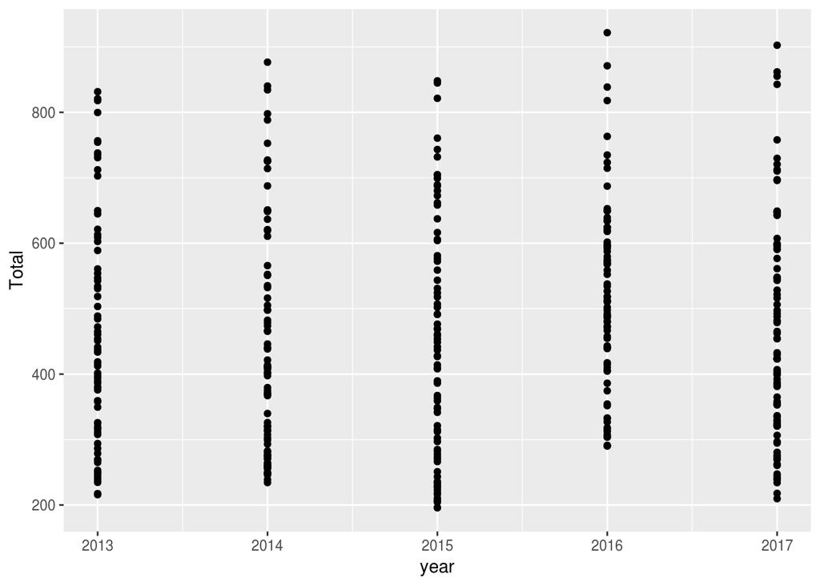

```r
library(tidyverse)

res2017 <- read.csv("fsae_mi_2017.csv")
res2017$year <- 2017
res2016 <- read.csv("fsae_mi_2016.csv")
res2016$year <- 2016
res2015 <- read.csv("fsae_mi_2015.csv")
res2015$year <- 2015
res2014 <- read.csv("fsae_mi_2014.csv")
res2014$year <- 2014
res2013 <- read.csv("fsae_mi_2013.csv")
res2013$year <- 2013

restdl <- do.call("rbind", list(res2017,res2016,res2015,res2014,res2013))

pt <- ggplot(restdl) +
  geom_point(aes(x=year, y = Total))
pt
```

### Observations

1. data appears to be clustered
2. a lot of point difference at the top points compared to the rest
3. on average, increasing total point values awarded, even over these 5 years.

```r
gatherpairs <- function(data, ..., xkey = '.xkey', xvalue = '.xvalue', ykey = '.ykey', yvalue = '.yvalue', na.rm = FALSE, convert = FALSE, factor_key = FALSE) {
  vars <- quos(...)
  xkey <- enquo(xkey)
  xvalue <- enquo(xvalue)
  ykey <- enquo(ykey)
  yvalue <- enquo(yvalue)

  data %>% {
    cbind(gather(., key = !!xkey, value = !!xvalue, !!!vars, na.rm = na.rm, convert = convert, factor_key = factor_key), dplyr::select(., !!!vars))
  }   %>% gather(., key = !!ykey, value = !!yvalue, !!!vars, na.rm = na.rm, convert = convert, factor_key = factor_key)
}
```

## Dynamic Events

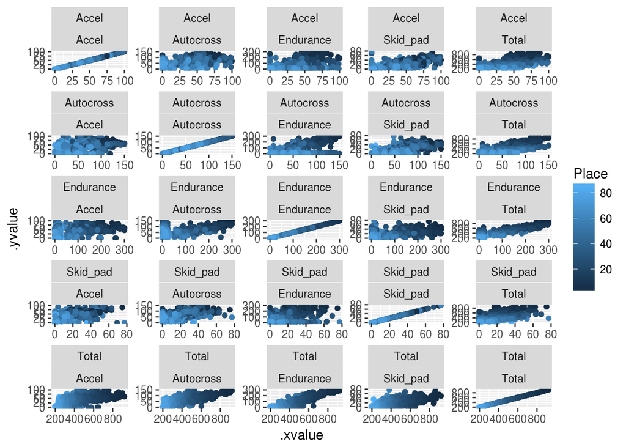

```r
restdl %>% gatherpairs( Accel, Skid_pad, Autocross, Endurance, Total) %>%
  ggplot(aes(x = .xvalue, y = .yvalue, color = Place), alpha = 0.2) +
  geom_point() +
  facet_wrap(.xkey ~ .ykey, scales = 'free')
```

### Takeaways

1. your Endurance score is dirrectly correlated with your placement
2. Autocross and Endurance are highly correlated (when the cars complete endurance)
3. Accel shows diminishing gains but is still correlated with total points
4. skidpad is a good early indicator of who will do well in autocross and endurance

## Static Events

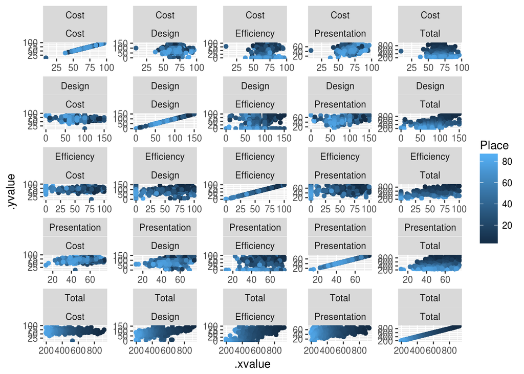

```r
restdl %>% gatherpairs( Cost, Presentation, Design, Efficiency, Total) %>%
  ggplot(aes(x = .xvalue, y = .yvalue, color = Place), alpha = 0.2) +
  geom_point() +
  facet_wrap(.xkey ~ .ykey, scales = 'free')
```

### Takeaways

1. don’t start focusing on Design until you are sure your car is over 600pts
2. anyone can win the presentation event, its free points if you dedicate the time
3. Efficiency is volitile, go hunting here for points as a last resort
4. the faster cars tend to run more expensive, it could be a way to get an edge

## look more closely year to year

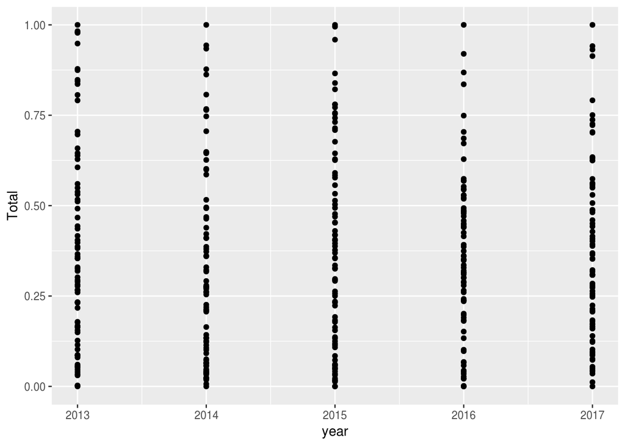

```r
normaliz <- function(value) {
  (value - min(value)) / (max(value) - min(value))
}


rt17 <- data.frame(Team = res2017$Team, year = res2017$year,  sapply(res2017[4:13], function(x) normaliz(x)))
rt16 <- data.frame(Team = res2016$Team, year = res2016$year, sapply(res2016[4:13], function(x) normaliz(x)))
rt15 <- data.frame(Team = res2015$Team, year = res2015$year, sapply(res2015[4:13], function(x) normaliz(x)))
rt14 <- data.frame(Team = res2014$Team, year = res2014$year, sapply(res2014[4:13], function(x) normaliz(x)))
rt13 <- data.frame(Team = res2013$Team, year = res2013$year, sapply(res2013[4:13], function(x) normaliz(x)))

restdl <- do.call("rbind", list(rt17, rt16, rt15, rt14, rt13))

pt <- ggplot(restdl) +
  geom_point(aes(x=year, y = Total))
pt
```

### Team Trends

```r
# look at only teams that are in dataset for all 5 years
# plot each team's trend
#
sbst <- table(restdl$Team)

sbst <- ifelse(sbst<5, FALSE, TRUE)

trnds <- data.frame(matrix(vector(), 0, 12))
names(trnds) <- names(restdl)
for(i in 1:nrow(restdl)){
  id <- restdl$Team[i]

    if(sbst[which(names(sbst)==id)] == TRUE){
      trnds <- rbind(trnds, restdl[i,])

  }
}

nrow(trnds)/5
```

```
[1] 27
```

```r
trnds$Team <- as.factor(as.character((trnds$Team)))
trnds[is.na(trnds)] <- 0
tmanes <- names(table(trnds$Team))
```

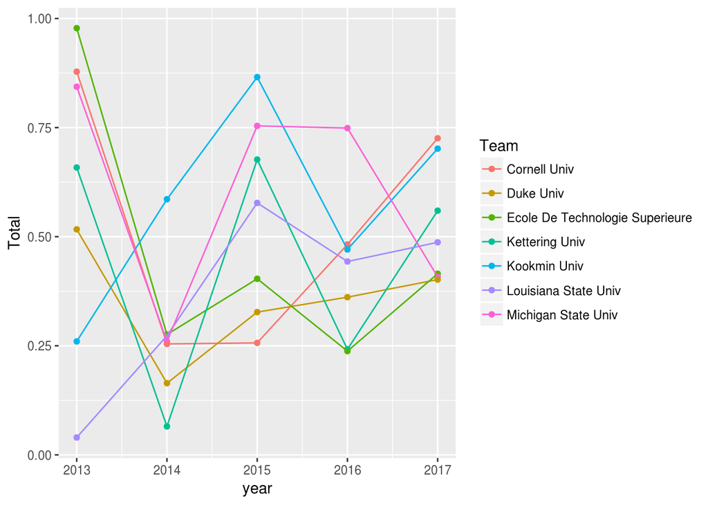

```r
trnds.sb <- trnds[which(trnds$Team %in% tmanes[1:7]),]
pt <- ggplot(trnds.sb) +
  geom_point(aes(x = year, y = Total, col = Team)) +
  geom_line(aes(x = year, y = Total, col = Team)) +
  xlim(2013, 2017)
pt
```

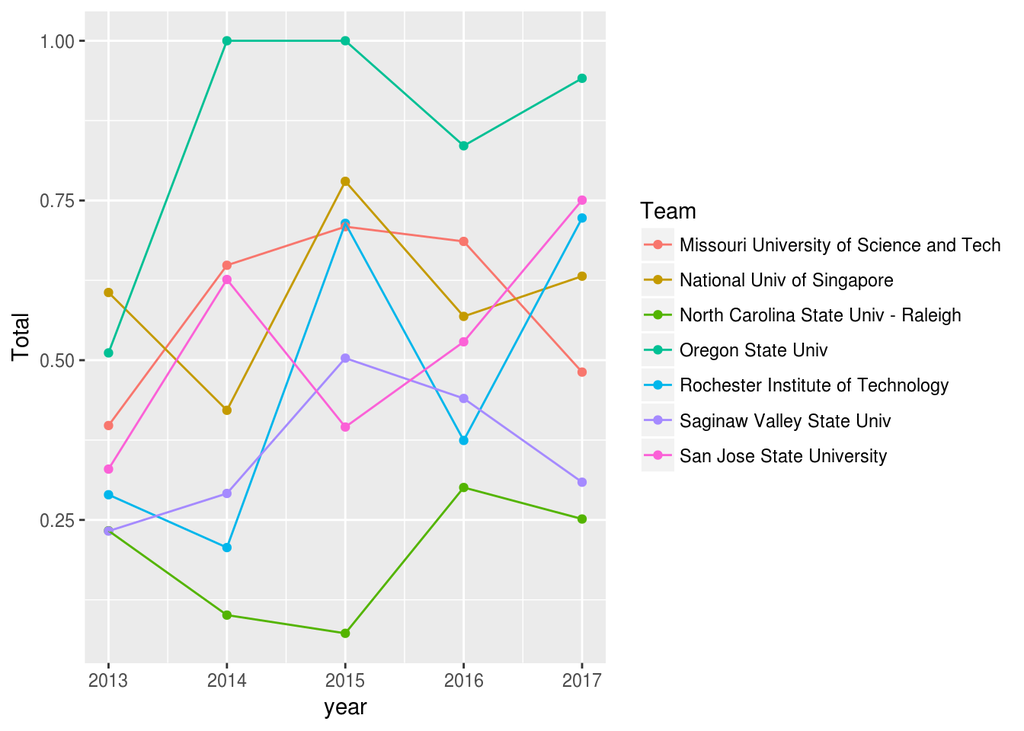

```r
trnds.sb <- trnds[which(trnds$Team %in% tmanes[8:14]),]
pt <- ggplot(trnds.sb) +
  geom_point(aes(x = year, y = Total, col = Team)) +
  geom_line(aes(x = year, y = Total, col = Team)) +
  xlim(2013, 2017)
pt
```

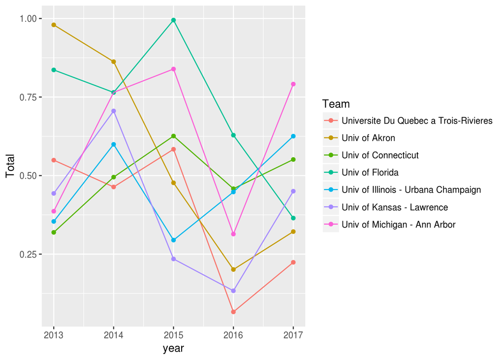

```r
trnds.sb <- trnds[which(trnds$Team %in% tmanes[15:21]),]
pt <- ggplot(trnds.sb) +
  geom_point(aes(x = year, y = Total, col = Team)) +
  geom_line(aes(x = year, y = Total, col = Team)) +
  xlim(2013, 2017)
pt
```

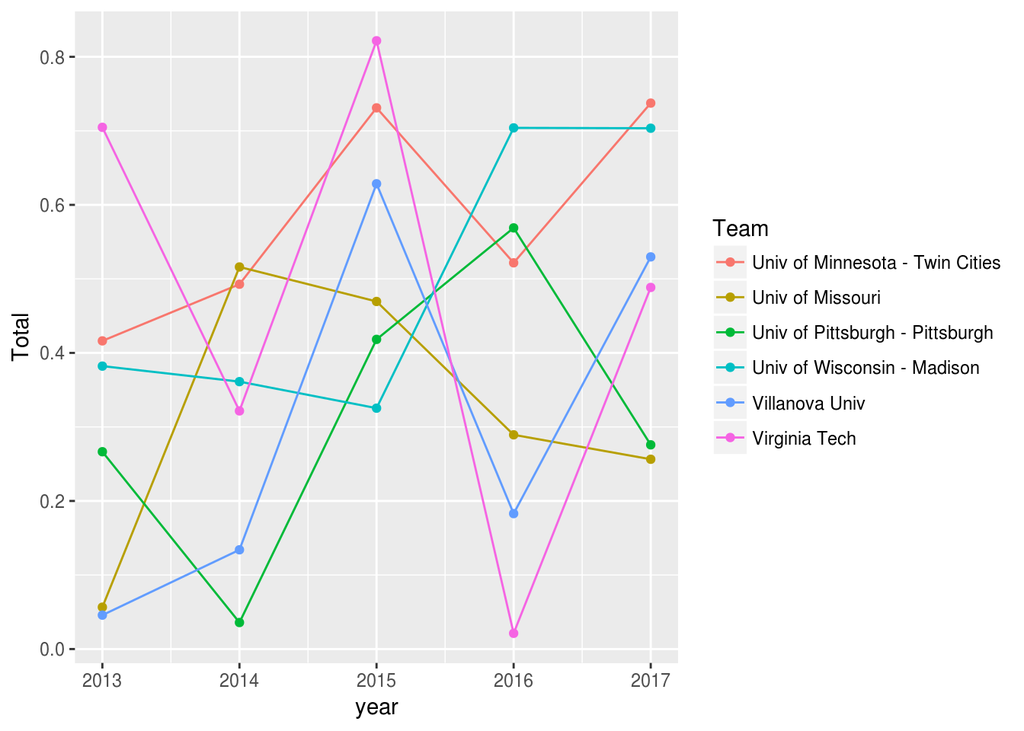

```r
trnds.sb <- trnds[which(trnds$Team %in% tmanes[22:27]),]
pt <- ggplot(trnds.sb) +
  geom_point(aes(x = year, y = Total, col = Team)) +
  geom_line(aes(x = year, y = Total, col = Team)) +
  xlim(2013, 2017)
pt
```

### cluster groups on pca

The Team name and year of competition are not included in the fit. Team name is ultimately what we want to know from this clustering so including it in the cluster will produce weird fits. The year of competition should have been accounted for in the normalization process (everything rescaled on [0,1] with only teams that competed in every year included in the dataset) so it is safe to not include it in this fit.

```r
pca <- prcomp(trnds[3:12])
print(pca)
```

```
Standard deviations (1, .., p=10):
 [1] 0.50869913 0.29011073 0.22780711 0.19619989 0.17270780 0.16121761
 [7] 0.14697102 0.13148510 0.11457498 0.04318753

Rotation (n x k) = (10 x 10):
                     PC1         PC2         PC3         PC4         PC5
Penalty      -0.01389279 -0.07337328  0.05008693 -0.05246799  0.09364185
Cost         -0.04565718 -0.08302370 -0.32942628 -0.06733830  0.31294518
Presentation  0.02696835  0.24878398 -0.61850815 -0.62297777 -0.08627202
Design        0.09268347  0.26220517 -0.20900222  0.01889355 -0.30975303
Accel         0.17686791  0.42162765  0.54729028 -0.53237308  0.37908970
Skid_pad      0.17308035  0.62136832  0.13494888  0.35535504 -0.18227626
Autocross     0.17277531  0.34702378 -0.27241912  0.33779261  0.07054597
Endurance     0.57794705 -0.25488616 -0.13427905  0.17525077  0.50410589
Efficiency    0.59933703 -0.30655872  0.16454541 -0.22012745 -0.58170652
Total         0.45175973  0.11764028 -0.16024754  0.03582334  0.12446332
                     PC6         PC7         PC8         PC9        PC10
Penalty       0.16583318 -0.20078403 -0.40441355 -0.86156376 -0.08207103
Cost         -0.70130545 -0.28378594  0.39432215 -0.22818058  0.01056180
Presentation  0.01659361  0.05846543 -0.36090588  0.11999681  0.10457962
Design        0.46347131 -0.51668908  0.52144201 -0.11765958  0.12309989
Accel         0.02124537  0.05277739  0.21675199 -0.05336406  0.10594883
Skid_pad     -0.37814971 -0.32280083 -0.38550344  0.08938204  0.04931458
Autocross     0.03137252  0.65671004  0.19849196 -0.32775094  0.27813375
Endurance     0.19735121 -0.23138402 -0.18351259  0.19171873  0.36772924
Efficiency   -0.27626052  0.11079969  0.06621356 -0.14679833  0.13554589
Total         0.07673879  0.06853075  0.07583144  0.02889845 -0.84997022
```

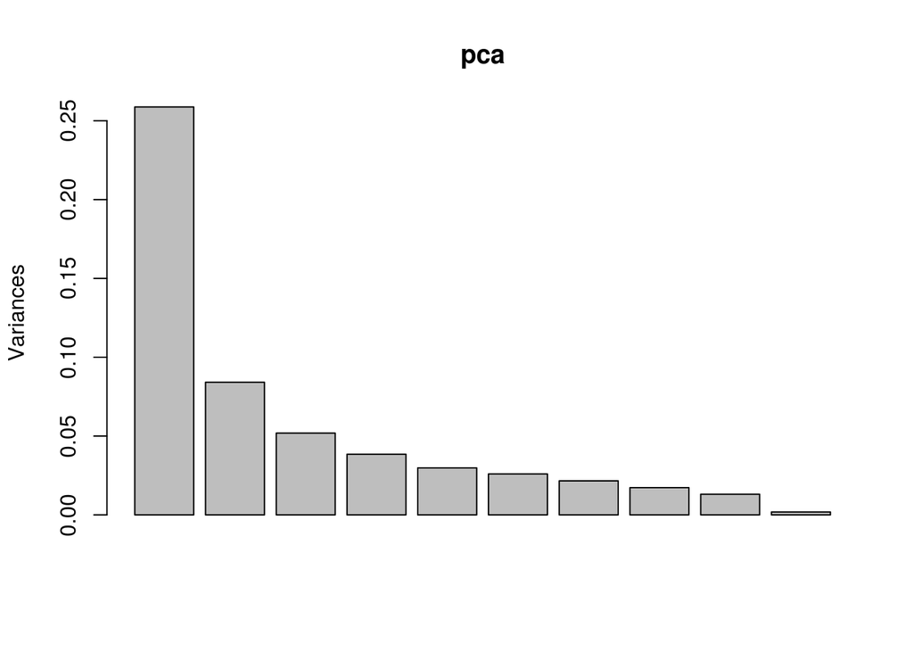

```r
plot(pca)
```

Based on the plot, the top 3 principal components will be used PC1 = Endurance, Efficiency, Total Points PC2 = Acceleration, Skid_pad PC3 = Acceleration, Presentation

### Cluster Teams

plot data on the first 2 principal components

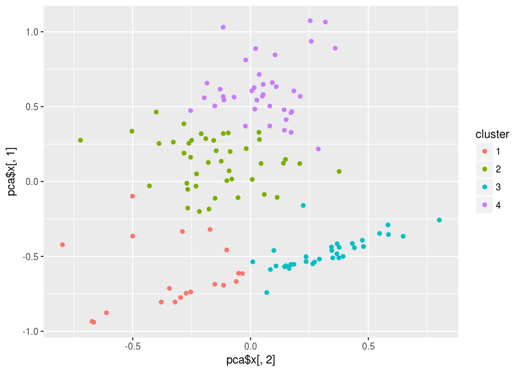

```r
topteams <- kmeans(pca$x[,1:3], centers = 4, iter.max = 100, nstart = 1000,  algorithm = "Hartigan-Wong")
trnds$cluster <- as.factor(topteams$cluster)

pt <- ggplot(trnds) +
  geom_point(aes(x = pca$x[,2], y = pca$x[,1], col = cluster))
pt
```

Looking at the data on the previous axes we have been looking at.

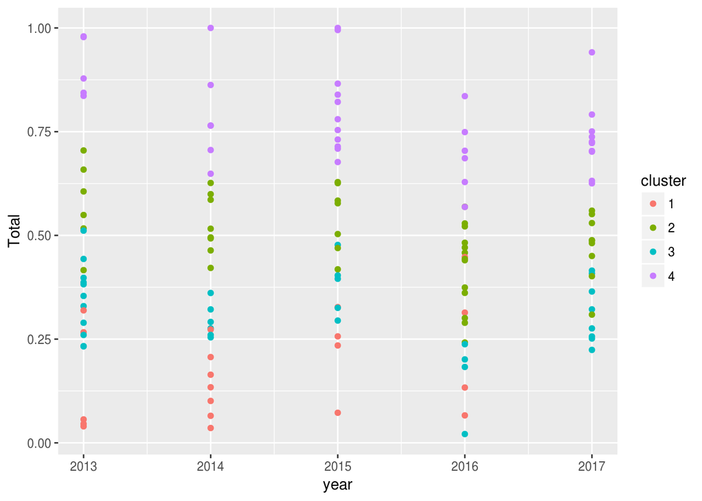

```r
pt <- ggplot(trnds) +
  geom_point(aes(x = year, y = Total, col = cluster))
pt
```

The 27 teams we were investigating and their most often associated cluster: (alphebetical by team name)

```r
clanes <- vector(length = 27)
for(i in 1:length(tmanes)){
  results <- as.numeric(trnds[which(trnds$Team %in% tmanes[i]),]$cluster)
  clanes[i] <- as.numeric(names(which.max(table(results))))

}

print(data.frame(Team = tmanes,cluster = clanes))
```

```
                                      Team cluster
1                             Cornell Univ       4
2                                Duke Univ       2
3          Ecole De Technologie Superieure       3
4                           Kettering Univ       2
5                             Kookmin Univ       2
6                     Louisiana State Univ       2
7                      Michigan State Univ       4
8  Missouri University of Science and Tech       4
9               National Univ of Singapore       4
10     North Carolina State Univ - Raleigh       1
11                       Oregon State Univ       4
12       Rochester Institute of Technology       4
13               Saginaw Valley State Univ       2
14               San Jose State University       2
15   Universite Du Quebec a Trois-Rivieres       2
16                           Univ of Akron       3
17                     Univ of Connecticut       2
18                         Univ of Florida       4
19     Univ of Illinois - Urbana Champaign       3
20               Univ of Kansas - Lawrence       1
21            Univ of Michigan - Ann Arbor       4
22         Univ of Minnesota - Twin Cities       2
23                        Univ of Missouri       2
24         Univ of Pittsburgh - Pittsburgh       1
25             Univ of Wisconsin - Madison       3
26                          Villanova Univ       1
27                           Virginia Tech       2
```

### Predict All Team Clusters

```r
library(clue)
pca.all <- predict(pca, newdata = restdl[3:12])
teamcl <- cl_predict(topteams, pca.all[,1:3])
tmanes.n <- names(table(restdl$Team))
restdl$cluster <- as.factor(teamcl)


for(i in 1:length(tmanes.n)){
  results <- as.numeric(restdl[which(restdl$Team %in% tmanes.n[i]),]$cluster)
  clanes[i] <- as.numeric(names(which.max(table(results))))

}
print(data.frame(team = tmanes.n,cluster = clanes))
```

```
                                       team cluster
1                                Brown Univ       2
2                             Carleton Univ       2
3                     Central Michigan Univ       2
4                              Clemson Univ       1
5                              Cooper Union       1
6                              Cornell Univ       4
7                                 Duke Univ       2
8           Ecole De Technologie Superieure       3
9    Embry-Riddle Aero Univ - Daytona Beach       1
10                    Florida Atlantic Univ       2
11                     Florida Inst of Tech       1
12                  Grand Valley State Univ       1
13                      Graz Technical Univ       4
14    Indiana Univ Purdue Univ Indianapolis       1
```

[output cut: 136 more lines]